# GIS in R - Rasters and Points

### Creating shapefiles and intersecting shapes and rasters

We can turn our points into a shapefile by specifying a cooordinate system. We will get the coordinate system from our raster

```r
myCrs <- projection(my_clim_stack) # get projection info

# make into points file
my_sites_shape <- SpatialPointsDataFrame(coords=my_sites, data=my_sites, proj4string=CRS(myCrs))
my_sites_shape
```

```
## class       : SpatialPointsDataFrame
## features    : 10
## extent      : -113.9729, 101.5795, 25.99265, 58.90141  (xmin, xmax, ymin, ymax)
## crs         : +proj=longlat +datum=WGS84 +no_defs
## variables   : 5
## names       :    longitude,    latitude, mean_diurnal_range, temperature_seasonality, precip_driest_quarter
## min values  : -113.9729092,  25.9926519,    6.6395206451416,        410.773773193359,                     1
## max values  :   101.579461, 58.90141071,   16.2268962860107,        1373.39074707031,                   245
```

Now let’s plot this shapefile along with the other elements.

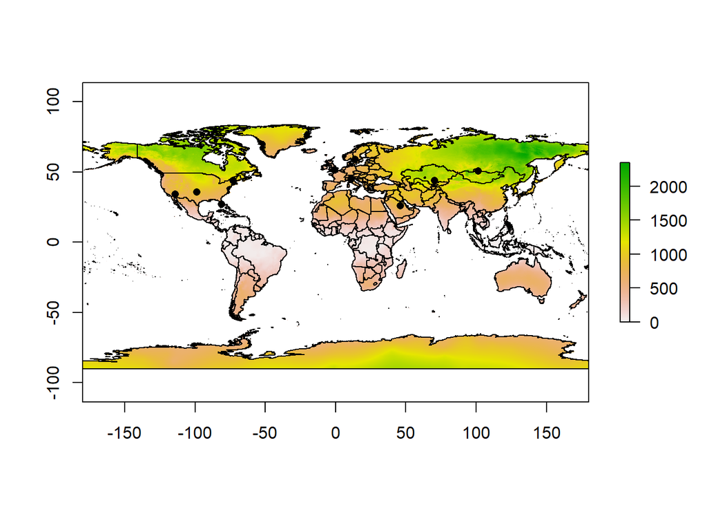

```r
plot(my_clim_stack[[2]])
plot(countries, add=TRUE)
points(my_sites_shape, pch=16) # show sites on the map
```

If you want to save these points for later we can do that with `writeORG` function from the rgdal package

```r
writeOGR(mySitesShape, 'My_locations', 'my_sites_shape', driver='ESRI Shapefile')
```

What if we want to create a shape file of only the countries we have visited? We can intersect our points with the country shape file. But first we will need to ensure they are in the same map projection.

```r
projection(my_sites_shape)
```

```
## [1] "+proj=longlat +datum=WGS84 +no_defs"
```

```r
projection(countries)
```

```
## [1] "+proj=longlat +datum=WGS84 +no_defs"
```

Looks good!

Now we can identify the countries that contain our points

```r
# add a column to countries data frame with a unique number
countries$id <- 1:nrow(countries)

# see which countries points fall into
my_countries <- over(my_sites_shape, countries)
head(as.data.frame(my_countries)) # let's look at data frame portion
```

```
##        featurecla scalerank LABELRANK     SOVEREIGNT SOV_A3 ADM0_DIF LEVEL
## 1 Admin-0 country         0         3     Kazakhstan    KA1        1     1
## 2 Admin-0 country         0         3       Mongolia    MNG        0     2
## 3 Admin-0 country         0         2   Saudi Arabia    SAU        0     2
## 4 Admin-0 country         0         2          Italy    ITA        0     2
## 5 Admin-0 country         0         3         Sweden    SWE        0     2
## 6 Admin-0 country         0         2 United Kingdom    GB1        1     2
##                TYPE TLC          ADMIN ADM0_A3 GEOU_DIF        GEOUNIT GU_A3
## 1       Sovereignty   1     Kazakhstan     KAZ        0     Kazakhstan   KAZ
## 2 Sovereign country   1       Mongolia     MNG        0       Mongolia   MNG
## 3 Sovereign country   1   Saudi Arabia     SAU        0   Saudi Arabia   SAU
## 4 Sovereign country   1          Italy     ITA        0          Italy   ITA
## 5 Sovereign country   1         Sweden     SWE        0         Sweden   SWE
## 6           Country   1 United Kingdom     GBR        0 United Kingdom   GBR
##   SU_DIF        SUBUNIT SU_A3 BRK_DIFF           NAME      NAME_LONG BRK_A3
```

[output cut: 188 more lines]

This is only the data from the country polygons to get the actual country polygons to plot we have to do one more step.

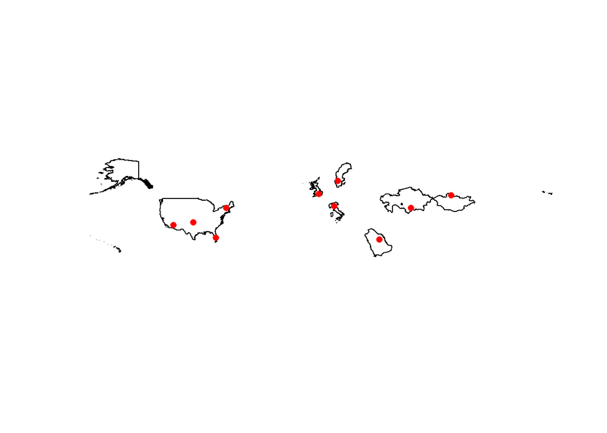

```r
my_countries <- countries[countries$id %in% my_countries$id, ] #select my countries from the country shape file by id #
# now let's plot just my countries
plot(my_countries)
points(my_sites_shape, col='red', pch=16)
```

We can then use `my_countries` to subset the climate rasters.

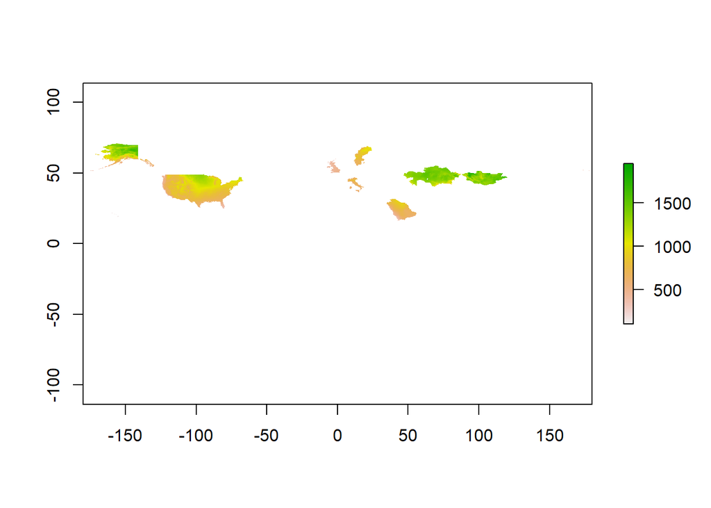

```r
# convert shapefile to raster
my_countries_mask <- rasterize(my_countries, my_clim_stack[[2]])
my_countries_mask <- my_countries_mask * 0 + 1 # make all values 1

my_clim_sites <- my_clim_stack[[2]] * my_countries_mask
plot(my_clim_sites)
```

### Selecting Random Points

To train our climate model we need a large set of random points to contrast agianst our selected locations. Ideally these would be locations where we were absent. However, if this is not practicable, a random selection of points can be sufficient.

```r
bg <- as.data.frame(randomPoints(my_clim_stack, n=10000)) # 10,000 random sites
names(bg) <- c('longitude', 'latitude')
head(bg)
```

```
##    longitude  latitude
## 1  -83.91667  35.25000
## 2   21.25000 -12.41667
## 3 -149.75000 -82.25000
## 4   20.08333 -17.58333
## 5   22.75000  66.75000
## 6   44.58333  30.25000
```

Note `select random points takes into account the curvature of the earth and you will see a lower density of random points where the projection has enlarged a feature (e.g. Greenland)

Lest take a look at our random or background (bg) points

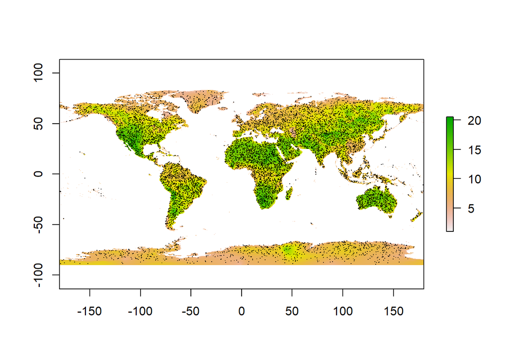

```r
plot(my_clim_stack[[1]])
points(bg, pch='.') # plot on map
```

Now lets extract the climate values at these points and combine them with the bg data set of locations.

```r
# extract enviro variables for the random points
bgEnv <- as.data.frame(extract(my_clim_stack, bg))
head(bgEnv)
```

```
##   mean_diurnal_range temperature_seasonality precip_driest_quarter
## 1          12.942896                721.4316                   356
## 2          14.958521                199.6431                     2
## 3           6.557916               1000.7164                     9
## 4          15.914250                340.9404                     1
## 5           8.738459                997.5553                    89
## 6          14.830105                929.9492                     0
```

```r
bg <- cbind(bg, bgEnv)
head(bg)
```

```
##    longitude  latitude mean_diurnal_range temperature_seasonality
## 1  -83.91667  35.25000          12.942896                721.4316
## 2   21.25000 -12.41667          14.958521                199.6431
## 3 -149.75000 -82.25000           6.557916               1000.7164
## 4   20.08333 -17.58333          15.914250                340.9404
## 5   22.75000  66.75000           8.738459                997.5553
## 6   44.58333  30.25000          14.830105                929.9492
##   precip_driest_quarter
## 1                   356
## 2                     2
## 3                     9
## 4                     1
## 5                    89
## 6                     0
```

### The Model

To start we will combine our site data with the background points and create a varaible `pres_bg` that indicates my point as a `1` and background as a `0`.

```r
pres_bg <- c(rep(1, nrow(my_sites)), rep(0, nrow(bg)))

train_data <- data.frame(
    pres_bg=pres_bg,
    rbind(my_sites, bg)
)

head(train_data)
```

```
##   pres_bg   longitude latitude mean_diurnal_range temperature_seasonality
## 1       1  70.3161401 43.81823          13.174375               1223.1614
## 2       1 101.5794610 50.67422          14.276125               1373.3907
## 3       1  45.9088107 25.99265          13.974229                868.3943
## 4       1  10.8061346 44.64095          10.608021                778.4135
## 5       1  13.8227708 58.90141           6.639521                654.0322
## 6       1  -0.9861706 51.49694           7.916042                474.6800
##   precip_driest_quarter
## 1                    12
## 2                     8
## 3                     1
## 4                   163
## 5                    98
## 6                   149
```

Now we are ready to train the model. We will use a generalized linear model (glm) with `pres_bg` as the dependent variable and our climate variables as independent variables. Since this is a binary outcome and quadratic model provides a good starting point.

```r
my_model <- glm(
    pres_bg ~ mean_diurnal_range*temperature_seasonality*precip_driest_quarter + I(mean_diurnal_range^2) + I(temperature_seasonality^2) + I(precip_driest_quarter^2),
    data=train_data,
    family='binomial',
    weights=c(rep(1, nrow(my_sites)), rep(nrow(my_sites) / nrow(bg), nrow(bg)))
)
```

```
## Warning: glm.fit: fitted probabilities numerically 0 or 1 occurred
```

```r
summary(my_model)
```

```
##
## Call:
## glm(formula = pres_bg ~ mean_diurnal_range * temperature_seasonality *
##     precip_driest_quarter + I(mean_diurnal_range^2) + I(temperature_seasonality^2) +
##     I(precip_driest_quarter^2), family = "binomial", data = train_data,
##     weights = c(rep(1, nrow(my_sites)), rep(nrow(my_sites)/nrow(bg),
##         nrow(bg))))
##
## Deviance Residuals:
##      Min        1Q    Median        3Q       Max
## -0.13318  -0.03052  -0.00782  -0.00078   0.96622
##
## Coefficients:
##                                                                    Estimate
## (Intercept)                                                       6.678e+00
## mean_diurnal_range                                               -9.630e-01
## temperature_seasonality                                          -1.484e-02
## precip_driest_quarter                                            -7.824e-02
## I(mean_diurnal_range^2)                                          -6.903e-02
## I(temperature_seasonality^2)                                     -1.639e-05
## I(precip_driest_quarter^2)                                       -1.383e-04
## mean_diurnal_range:temperature_seasonality                        3.799e-03
## mean_diurnal_range:precip_driest_quarter                          1.327e-02
## temperature_seasonality:precip_driest_quarter                     1.859e-04
## mean_diurnal_range:temperature_seasonality:precip_driest_quarter -1.894e-05
##                                                                  Std. Error
## (Intercept)                                                       2.159e+01
## mean_diurnal_range                                                2.758e+00
## temperature_seasonality                                           2.841e-02
## precip_driest_quarter                                             1.895e-01
## I(mean_diurnal_range^2)                                           1.196e-01
## I(temperature_seasonality^2)                                      1.146e-05
## I(precip_driest_quarter^2)                                        1.404e-04
## mean_diurnal_range:temperature_seasonality                        2.851e-03
## mean_diurnal_range:precip_driest_quarter                          1.692e-02
## temperature_seasonality:precip_driest_quarter                     2.777e-04
## mean_diurnal_range:temperature_seasonality:precip_driest_quarter  2.423e-05
##                                                                  z value
## (Intercept)                                                        0.309
## mean_diurnal_range                                                -0.349
```

[output cut: 14 more lines]

```
## I(mean_diurnal_range^2)                                             0.564
## I(temperature_seasonality^2)                                        0.153
## I(precip_driest_quarter^2)                                          0.325
## mean_diurnal_range:temperature_seasonality                          0.183
## mean_diurnal_range:precip_driest_quarter                            0.433
## temperature_seasonality:precip_driest_quarter                       0.503
## mean_diurnal_range:temperature_seasonality:precip_driest_quarter    0.434
##
## (Dispersion parameter for binomial family taken to be 1)
##
##     Null deviance: 27.726  on 10009  degrees of freedom
## Residual deviance: 14.205  on  9999  degrees of freedom
## AIC: 27.154
##
## Number of Fisher Scoring iterations: 8
```

We will ignore the warning and we are not going to put to much stock in the statistical significance of the variables in the model. Our glm does not account for spatial autocorrelation, so these are likely inflated. However, we can use the model to make useful predictions and characterize suitable habitat given our selected points.

```r
my_world <- predict(
  my_clim_stack,
  my_model,
  type='response'
)

my_world
```

```
## class      : RasterLayer
## dimensions : 1080, 2160, 2332800  (nrow, ncol, ncell)
## resolution : 0.1666667, 0.1666667  (x, y)
## extent     : -180, 180, -90, 90  (xmin, xmax, ymin, ymax)
## crs        : +proj=longlat +datum=WGS84 +no_defs
## source     : memory
## names      : layer
## values     : 2.220446e-16, 0.9999005  (min, max)
```

What does my world look like?

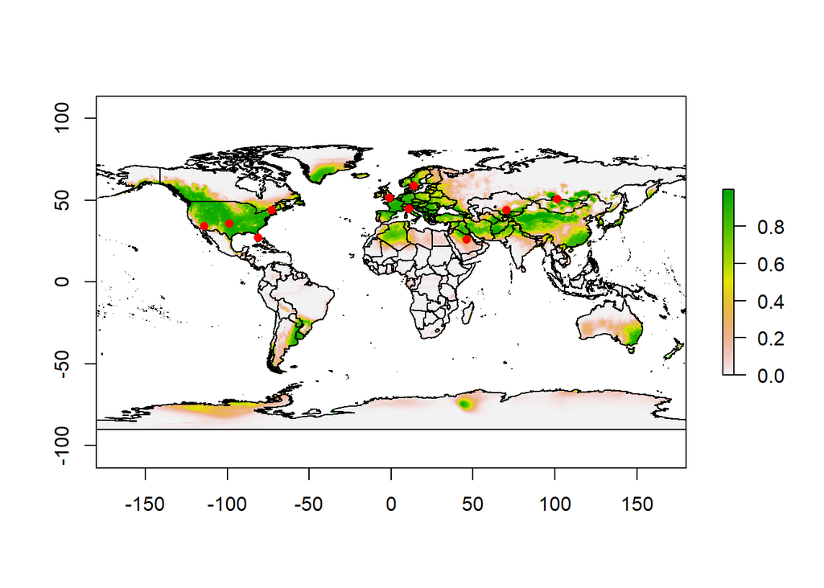

```r
plot(my_world)
plot(countries, add=TRUE)
points(my_sites_shape, col='red', pch=16)
```

The closer a point is to `1` the better match it is to the points I selected.

Let’s save this raster, we may need it later!

```r
writeRaster(my_world, 'My_Climate_Niche/my_world', format='GTiff', overwrite=TRUE, progress='text')
```

We have now defined our climate preference. We can further compare this to the global environment by setting a threshold to select the top 25% most preferred regions and comparing to the globe as a whole.

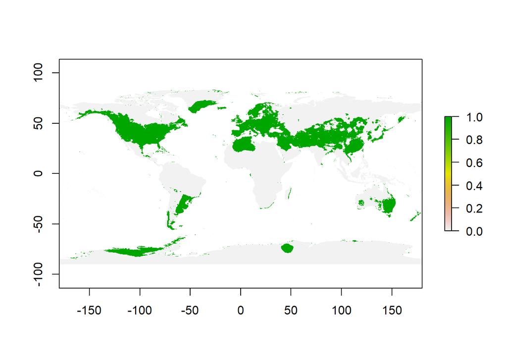

```r
# threshold your "preferred" climate
my_world_thresh <- my_world >= quantile(my_world, 0.75)
plot(my_world_thresh)
```

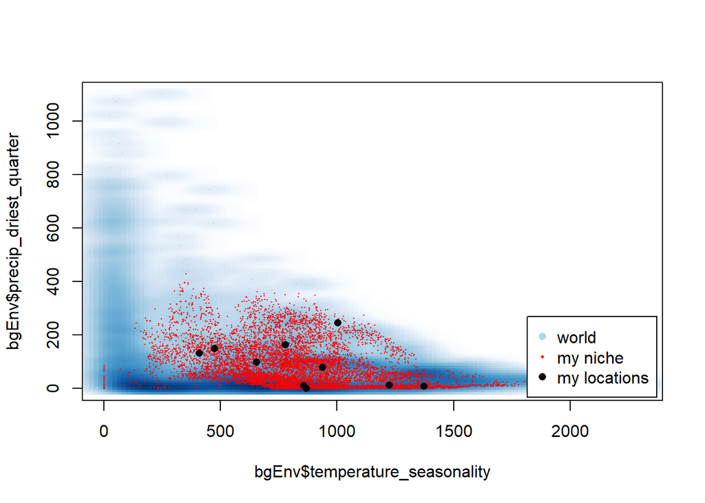

```r
# convert all values not equal to 1 to NA...
# using "calc" function to implement a custom function
my_world_thresh <- calc(my_world_thresh, fun=function(x) ifelse(x==0 | is.na(x), NA, 1))

# get random sites
my_best_sites <- randomPoints(my_world_thresh, 10000)
my_best_env <- as.data.frame(extract(my_clim_stack, my_best_sites))

# plot world's climate
smoothScatter(x=bgEnv$temperature_seasonality, y=bgEnv$precip_driest_quarter, col='lightblue')
points(my_best_env$temperature_seasonality, my_best_env$precip_driest_quarter, col='red', pch=16, cex=0.2)
points(my_sites$temperature_seasonality, my_sites$precip_driest_quarter, pch=16)
legend(
  'bottomright',
  inset=0.01,
  legend=c('world', 'my niche', 'my locations'),
  pch=16,
  col=c('lightblue', 'red', 'black'),
  pt.cex=c(1, 0.4, 1)

)
```

Looks like my climate niche is dry and temperate regions!

```
This lesson was adapted with permission from Adam Smith: http://www.earthskysea.org/.
```